# rMiW: 02. rMiW & BioImageDbs for a workflow for microscopy-based image analysis and U-Net model

Satoshi Kume

satoshi.kume.1984@gmail.com

2021-11-04

#### Package

rMiW, BioImageDbs

# Contents

**Last modified:** 2021-11-04 00:11:40  
**Compiled**: 2021-11-04 00:12:35

# 1 Getting started

## 1.1 Load packages

```r
library(ExperimentHub)
library(rMiW)
library(EBImage)
library(keras)

packageVersion("keras")
```

```
## [1] '2.6.1'
```

```r
packageVersion("tensorflow")
```

```
## [1] '2.6.0'
```

## 1.2 Optional: Update (ver 3.14)

```r
BiocManager::install(version = "3.14")
```

## 1.3 Optional: Python environment on R

```r
#On MacOSX
library(reticulate)
#reticulate::install_miniconda(force = T)
#reticulate::use_python("~/Library/r-miniconda/envs/r-reticulate/bin/python")
reticulate::py_config()

#install pydot
#reticulate::py_install("pydot")

#On CentOS
library(reticulate)
#reticulate::install_miniconda(force = T)
#reticulate::use_python("~/.local/share/r-miniconda/envs/r-reticulate/bin/python")
reticulate::py_config()
```

## 1.4 Optional: install python packages for R keras / tensorflow (ver 3.14)

```r
#For CPU
keras::install_keras()
```

## 1.5 Optional: Removes all files in the cache directory

```r
install.packages("R.cache")
#system("open ~/Library/Caches/org.R-project.R/R/")
R.cache::clearCache("~/Library/Caches/org.R-project.R/R/ExperimentHub")
```

## 1.6 Optional: extract R script from the Rmd file

```r
knitr::purl("./rMiW/vignettes/rMiW_02_BioImageDbs.Rmd", output="./rMiW/vignettes/rMiW_02_BioImageDbs.R")
```

# 2 Obtain 2D image dataset via BioImageDbs

About the BioImageDbs package, please ckeck [Providing Bioimage Dataset for ExperimentHub](https://bioconductor.org/packages/release/data/experiment/vignettes/BioImageDbs/inst/doc/BioImageDbs.html) document for more information.

Please check [the metadata (CSV) of BioImageDbs](https://github.com/kumeS/BioImageDbs/blob/main/inst/extdata/v02/metadata_v02.csv) in GitHub.

```r
#Description: Providing Bioimage Dataset for ExperimentHub
browseURL("https://bioconductor.org/packages/release/data/experiment/vignettes/BioImageDbs/inst/doc/BioImageDbs.html")

#Metadata (CSV) for BioImageDbs
browseURL("https://github.com/kumeS/BioImageDbs/blob/main/inst/extdata/v02/metadata_v02.csv")
```

## 2.1 Search query for the BioImageDbs

Via the ExperimentHub function, we can obtain the supervised image data as a list of R arrays and their metadata.

Here shows an example of a search query for the BioImageDbs (Currently, `snapshotDate(): 2021-10-18` for version 3.14).

```r
#Set the ExperimentHub function
eh <- ExperimentHub::ExperimentHub()
```

```
## snapshotDate(): 2021-10-18
```

```r
#All entities of BioImageDbs
AnnotationHub::query(eh, c("BioImageDbs"))
```

```
## ExperimentHub with 96 records
## # snapshotDate(): 2021-10-18
## # $dataprovider: Satoshi Kume <satoshi.kume.1984@gmail.com>, CELL TRACKING C...
## # $species: Mus musculus, Homo sapiens, Rattus norvegicus, Drosophila melano...
## # $rdataclass: List, magick-image
## # additional mcols(): taxonomyid, genome, description,
## #   coordinate_1_based, maintainer, rdatadateadded, preparerclass, tags,
## #   rdatapath, sourceurl, sourcetype
## # retrieve records with, e.g., 'object[["EH6851"]]'
##
##            title
##   EH6851 | EM_id0001_Brain_CA1_hippocampus_region_5dTensor.rds
##   EH6852 | EM_id0001_Brain_CA1_hippocampus_region_5dTensor_train_dataset.gif
##   EH6853 | EM_id0002_Drosophila_brain_region_5dTensor.rds
##   EH6854 | EM_id0002_Drosophila_brain_region_5dTensor_train_dataset.gif
##   EH6855 | LM_id0001_DIC_C2DH_HeLa_4dTensor.rds
##   ...      ...
##   EH6942 | EM_id0009_MurineBMMC_All_512_4dTensor_dataset.gif
##   EH6943 | EM_id0010_HumanBlast_All_512_4dTensor.Rds
##   EH6944 | EM_id0010_HumanBlast_All_512_4dTensor_dataset.gif
##   EH6945 | EM_id0011_HumanJurkat_All_512_4dTensor.Rds
##   EH6946 | EM_id0011_HumanJurkat_All_512_4dTensor_dataset.gif
```

```r
#Query with LM_id0001 (Light Microscopy ID 0001)
AnnotationHub::query(eh, c("BioImageDbs", "LM_id0001"))
```

```
## ExperimentHub with 10 records
## # snapshotDate(): 2021-10-18
## # $dataprovider: CELL TRACKING CHALLENGE (http://celltrackingchallenge.net/2...
## # $species: Homo sapiens
## # $rdataclass: List, magick-image
## # additional mcols(): taxonomyid, genome, description,
## #   coordinate_1_based, maintainer, rdatadateadded, preparerclass, tags,
## #   rdatapath, sourceurl, sourcetype
## # retrieve records with, e.g., 'object[["EH6855"]]'
##
##            title
##   EH6855 | LM_id0001_DIC_C2DH_HeLa_4dTensor.rds
##   EH6856 | LM_id0001_DIC_C2DH_HeLa_4dTensor_train_dataset.gif
##   EH6857 | LM_id0001_DIC_C2DH_HeLa_4dTensor_Binary.rds
##   EH6858 | LM_id0001_DIC_C2DH_HeLa_4dTensor_Binary_train_dataset.gif
##   EH6859 | LM_id0001_DIC_C2DH_HeLa_5dTensor.rds
##   EH6878 | LM_id0001_DIC_C2DH_HeLa_4dTensor.Rds
##   EH6879 | LM_id0001_DIC_C2DH_HeLa_4dTensor_train_dataset.gif
##   EH6880 | LM_id0001_DIC_C2DH_HeLa_4dTensor_Binary.Rds
##   EH6881 | LM_id0001_DIC_C2DH_HeLa_4dTensor_Binary_train_dataset.gif
##   EH6882 | LM_id0001_DIC_C2DH_HeLa_5dTensor.Rds
```

```r
#check 4d tensor of LM_id0001
(qr <- AnnotationHub::query(eh, c("BioImageDbs", "LM_id0001_DIC_C2DH_HeLa_4dTensor_Binary")))
```

```
## ExperimentHub with 4 records
## # snapshotDate(): 2021-10-18
## # $dataprovider: CELL TRACKING CHALLENGE (http://celltrackingchallenge.net/2...
## # $species: Homo sapiens
## # $rdataclass: magick-image, List
## # additional mcols(): taxonomyid, genome, description,
## #   coordinate_1_based, maintainer, rdatadateadded, preparerclass, tags,
## #   rdatapath, sourceurl, sourcetype
## # retrieve records with, e.g., 'object[["EH6857"]]'
##
##            title
##   EH6857 | LM_id0001_DIC_C2DH_HeLa_4dTensor_Binary.rds
##   EH6858 | LM_id0001_DIC_C2DH_HeLa_4dTensor_Binary_train_dataset.gif
##   EH6880 | LM_id0001_DIC_C2DH_HeLa_4dTensor_Binary.Rds
##   EH6881 | LM_id0001_DIC_C2DH_HeLa_4dTensor_Binary_train_dataset.gif
```

```r
#Select their metadata using `qr$`
#show title
qr$title
```

```
## [1] "LM_id0001_DIC_C2DH_HeLa_4dTensor_Binary.rds"
## [2] "LM_id0001_DIC_C2DH_HeLa_4dTensor_Binary_train_dataset.gif"
## [3] "LM_id0001_DIC_C2DH_HeLa_4dTensor_Binary.Rds"
## [4] "LM_id0001_DIC_C2DH_HeLa_4dTensor_Binary_train_dataset.gif"
```

```r
#show description
qr$description[3]
```

```
## [1] "4D arrays with the binary labels for the image segmentation. Human HeLa cells on a flat glass. The original dataset for 2D segmentation was provided by Dr. G. van Cappellen, Erasmus Medical Center, Rotterdam, The Netherlands. The dataset images were captured by the Zeiss LSM 510 Meta with th…
```

Note: small `.rds` data does not work. They will be removed in future.

## 2.2 Optional: Download from Google Drive

```r
file <- system.file("script", "gdrive_download.sh", package="rMiW")
system(paste0("source ", file, " ; gdrive_download 1J-wR0icTCpFgeKPP0iF4cyzD-b1m3tOO ./output.Rds"))
ImgData <- readRDS("output.Rds")
str(ImgData)
```

## 2.3 Acquire the image arrays

We use `[]` to access its metadata while `[[]]` to get its data instance.

We could load from cache (~/Library/Caches/org.R-project.R/R/) once the data was downloaded.

```r
#Access metadata
qr[3]
```

```
## ExperimentHub with 1 record
## # snapshotDate(): 2021-10-18
## # names(): EH6880
## # package(): BioImageDbs
## # $dataprovider: CELL TRACKING CHALLENGE (http://celltrackingchallenge.net/2...
## # $species: Homo sapiens
## # $rdataclass: List
## # $rdatadateadded: 2021-05-18
## # $title: LM_id0001_DIC_C2DH_HeLa_4dTensor_Binary.Rds
## # $description: 4D arrays with the binary labels for the image segmentation....
## # $taxonomyid: 9606
## # $genome: NA
## # $sourcetype: PNG
## # $sourceurl: https://github.com/kumeS/BioImageDbs
## # $sourcesize: NA
## # $tags: c("bioimage", "cell tracking", "CellCulture", "microscope",
## #   "segmentation", "Tissue")
## # retrieve record with 'object[["EH6880"]]'
```

```r
#Show metadata
qr[3]$title
```

```
## [1] "LM_id0001_DIC_C2DH_HeLa_4dTensor_Binary.Rds"
```

```r
qr[3]$description
```

```
## [1] "4D arrays with the binary labels for the image segmentation. Human HeLa cells on a flat glass. The original dataset for 2D segmentation was provided by Dr. G. van Cappellen, Erasmus Medical Center, Rotterdam, The Netherlands. The dataset images were captured by the Zeiss LSM 510 Meta with th…
```

```r
#Download the dataset of LM_id0001 (LM_id0001_DIC_C2DH_HeLa_4dTensor_Binary.rds)
ImgData <- qr[[3]]
```

```
## see ?BioImageDbs and browseVignettes('BioImageDbs') for documentation
```

```
## loading from cache
```

```r
str(ImgData)
```

```
## List of 2
##  $ Train:List of 2
##   ..$ Train_Original          : num [1:84, 1:512, 1:512, 1] 0.518 0.455 0.455 0.447 0.439 ...
##   ..$ Train_GroundTruth_Binary: num [1:84, 1:512, 1:512, 1] 0 0 0 0 0 0 0 0 0 0 ...
##  $ Test :List of 2
##   ..$ Test_Original          : num [1:84, 1:512, 1:512, 1] 0.604 0.467 0.459 0.435 0.408 ...
##   ..$ Test_GroundTruth_Binary: num [1:84, 1:512, 1:512, 1] 0 1 1 1 1 1 1 0 0 0 ...
```

```r
#List of 2
# $ Train:List of 2
#  ..$ Train_Original          : num [1:84, 1:512, 1:512, 1] 0.518 0.455 0.455 0.447 0.439 ...
#  ..$ Train_GroundTruth_Binary: num [1:84, 1:512, 1:512, 1] 0 0 0 0 0 0 0 0 0 0 ...
# $ Test :List of 2
#  ..$ Test_Original          : num [1:84, 1:512, 1:512, 1] 0.604 0.467 0.459 0.435 0.408 ...
#  ..$ Test_GroundTruth_Binary: num [1:84, 1:512, 1:512, 1] 0 1 1 1 1 1 1 0 0 0 ...
```

`LM_id0001_DIC_C2DH_HeLa_4dTensor_Binary.Rds` is a list of 4D arrays with the binary labels for the image segmentation of Human HeLa cells on a flat glass.

## 2.4 Show the gif animation

Here we will get a gif animation and check the result of data visualization.

```r
#Access metadata
qr[2]
```

```
## ExperimentHub with 1 record
## # snapshotDate(): 2021-10-18
## # names(): EH6858
## # package(): BioImageDbs
## # $dataprovider: CELL TRACKING CHALLENGE (http://celltrackingchallenge.net/2...
## # $species: Homo sapiens
## # $rdataclass: magick-image
## # $rdatadateadded: 2021-05-18
## # $title: LM_id0001_DIC_C2DH_HeLa_4dTensor_Binary_train_dataset.gif
## # $description: A animation file (.gif) of the train dataset of LM_id0001_DI...
## # $taxonomyid: 9606
## # $genome: NA
## # $sourcetype: PNG
## # $sourceurl: https://github.com/kumeS/BioImageDbs
## # $sourcesize: NA
## # $tags: c("animation", "bioimage", "cell tracking", "CellCulture",
## #   "microscope", "segmentation", "Tissue")
## # retrieve record with 'object[["EH6858"]]'
```

```r
#show metadata
qr[2]$title
```

```
## [1] "LM_id0001_DIC_C2DH_HeLa_4dTensor_Binary_train_dataset.gif"
```

```r
qr[2]$description
```

```
## [1] "A animation file (.gif) of the train dataset of LM_id0001_DIC_C2DH_HeLa_4dTensor_Binary.rds."
```

```r
#Get gif animation
GifData <- qr[[2]]
```

```
## see ?BioImageDbs and browseVignettes('BioImageDbs') for documentation
```

```
## loading from cache
```

```r
str(GifData)  # Data path
```

```
##  Named chr "/Users/skume/Library/Caches/org.R-project.R/R/ExperimentHub/8ac541541a28_6907"
##  - attr(*, "names")= chr "EH6858"
```

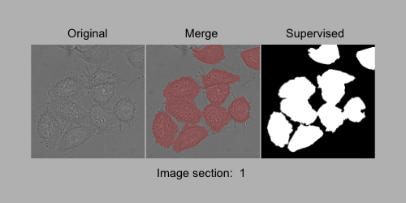

```r
magick::image_read(GifData)
```

`LM_id0001_DIC_C2DH_HeLa_4dTensor_Binary_train_dataset.gif` is an animation file (.gif) of the train dataset of LM_id0001_DIC_C2DH_HeLa_4dTensor_Binary.rds

Currently, only `magick::image_read` is supported to view gif animation files.